# Online learning Algorithms

2022-12-09

# Introduction

In this vignette we will implement code to carry out the following algorithms: Recursive Least Squares(RLS), Online Gradient Descent (OGD), and Adaptive Gradient Descent (AdaGrad). We will show you how these functions work with some simple examples. Finally we will show you how we gathered some of the results from our report.

# Recursive Least Squares

```r
run_RLS( Y,X,initial = 0,invxtx = 10^6 * diag(nrow = dim(X)[2], ncol = dim(X)[2]),xty = matrix(0, nrow = dim(X)[2], ncol = 1),btrue = rep(0, dim(X)[2]))
```

The function has several input arguments: Y is for your response vector, and X is for your design matrix.
Initial tells us how many data points you have used in your previous model. If initial is zero we will compute the estimate for the regression parameters from scratch. If initial is greater than 0 we will take your previous model (assuming later data points are added to the bottom of the design matrix) and update it to reflect any new data points received.
The function outputs are the regression parameter estimates, the estimation errors,and prediction errors, beta,eeps,peps respectively.
invxtx is
$$(X^{T}X)^{-1}$$
from your previous model. If there is no previous model we inialise the algorithm with
$$10^{6}I_{p}$$
where p is the number of regression parameters.
xty is the matrix
$$X^{T}y$$
from the previous model. If there is no previous model we initialise this with
$$\textbf{0}_{p}$$
.
btrue is used to input the true regression parameters and is included to allow for analysis.

## Example

Consider the following example where we have a design matrix
$$X = \left(\begin{array}{cc}
1 & 0 & 0\\
1 & 1 & 1 \\
1 & 2 & 3 \\
1 & 3 & 5\\
1 & 4 & 4 \\
1 & 5 & 4 \\
\end{array}\right)$$
$$y =
\left(\begin{array}{cc}
3\\
5 \\
6 \\
8\\
10\\
11\\
\end{array}\right)$$
Then
$$(X^{T}X)^{-1} = \left(\begin{array}{cc}
0.599 & -0.035 & -0.121\\
-0.035 & 0.211 & -0.174 \\
-0.121 & -0.174 & 0.196 \\
\end{array}\right)$$
and
$$X^{T}\textbf{y}=\left(\begin{array}{cc}
43\\
136 \\
147 \\
\end{array}\right)$$
Then the OLS estimate is
$${\hat{\beta}} = \left(\begin{array}{cc}
3.104\\
1.642 \\
-0.015 \\
\end{array}\right)$$
Now we will first produce the regression parameter estimates from scratch i.e. no previous model.

```r
library(onlinelearning)
testdata = c(1,0,0,1,1,1,1,2,3,1,3,5,1,4,4,1,5,4)
testdata = matrix(testdata,nrow = 6,ncol=3,byrow = TRUE)
response = c(3,5,6,8,10,11)
(beta = run_RLS(response,testdata)[1])
```

```
## [[1]]
##             [,1]
## [1,]  3.10447581
## [2,]  1.64179081
## [3,] -0.01492471
```

which gives us the OLS estimates as expected.  
If we already built a model from say the first three data points and we have just received three more data points we can then update our model.

```r
(beta = (run_RLS(response,testdata,3,solve(t(testdata[1:3,])%*%testdata[1:3,]),t(testdata[1:3,]) %*% response[1:3]))[1])
```

```
## [[1]]
##             [,1]
## [1,]  3.10447761
## [2,]  1.64179104
## [3,] -0.01492537
```

which again gives us the OLS estimates.

# Aside

```r
pred_error = function(reg, y, X, b_est) {
  if (reg=="linear") {
    # mean squared prediction error
    return(sum((y - X %*% b_est)^2)/nrow(X))
  } else if (reg=="logistic") {
    # classification error rate
    return(colMeans(sign(1/(1 + exp(-X%*%b_est))-0.5) != y))
  }
}
```

This function takes 4 input arguments.  
reg can take one of two options ““linear” or “logistic” for linear regression or logistic regression respectively.  
y is the response vector.  
X is the design matrix.  
b_est is our vector of estimates for the regression parameters.

```r
est_error = function(b_true, b_est){
  return(norm(b_true - b_est, type = "2"))
}
```

This function computes the estimation errors and has two input arguments.  
b_true are the known regression parameters.  
b_est is our vector of estimates for the regression parameters.

# Data generator function

```r
sample_iid_data( reg,n = 1000,b_len = 500,bn0_len = 100,signal = 5,noise = 1)
```

This function will be used to generate the data for the rest of our analyses.  
This has several inputs  
reg has two options “linear” and “logistic” for linear and logistic regression respectively.  
n, the number of data points we want to generate.  
b_len, the number of regression parameters.  
bno_len, is the number of non-zero regression parameters.  
signal, is the variance of the signal features.  
noise, is the variance of the error terms.  
The outputs are  
For linear regression, the response vector y, the design matrix X, the regression parameters b, and the error terms.  
For logistic regression, the response vector y, the design matrix X, the regression parameters b, and the vector of probabilities.

# Online gradient descent

```r
run_OGD(reg, y, X, b_true, learn_rate, PR_ave = TRUE)
```

This function has several inputs.  
reg, has two options “linear” or “logistic” for linear and logistic regression respectively.  
y: the response vector.  
X: the design matrix.  
b_true: the true regression parameters.  
learn_rate: fixed constant we multiply our changing learning rate by.  
PR_ave: whether we want to subject our estimates to Polyak-Ruppert averaging.  
The outputs are: regression parameter estimates (b_est), the true regression parameters (b_true), the estimation errors (est_error) at each iteration, and the prediction errors at each iteration (pred_error).

# Example

We can firstly simulate our regression data by

```r
set.seed(123)
regdata = sample_iid_data(reg = "linear", n=1000,b_len = 2000,bn0_len = 100,signal = 5,noise = 1)
```

We can then use OGD to estimate the regression parameters in the linear regression setting.

```r
regogdemp = run_OGD(reg = "linear", y = regdata$y, X = regdata$X, b_true = regdata$b, learn_rate = 0.006,PR_ave = FALSE)
```

We can do the same in the logistic regression setting.

```r
#Generate data
logdata = sample_iid_data(reg = "logistic", n=1000,b_len = 2000,bn0_len = 100)

#Use OGD to find the regression parameters
logogdemp = run_OGD(reg = "logistic", y = logdata$y, X = logdata$X, b_true = logdata$b, learn_rate = 0.3,PR_ave = FALSE)
```

# Adaptive gradient descent

```r
run_AdaGrad(reg, y, X, b_true, learn_rate, PR_ave = TRUE)
```

This function has several inputs.  
reg, has two options “linear” or “logistic” for linear and logistic regression respectively.  
y: the response vector.  
X: the design matrix.  
b_true: the true regression parameters.  
learn_rate: fixed constant we multiply our changing learning rate by.  
PR_ave: whether we want to subject our estimates to Polyak-Ruppert averaging.  
The outputs are: regression parameter estimates (b_est), the true regression parameters (b_true), the estimation errors (est_error) at each iteration, and the prediction errors at each iteration (pred_error).

# Example

We can estimate the regression parameters in the linear regression context using AGD.

```r
regagdemp = run_AdaGrad(reg = "linear", y = regdata$y, X = regdata$X, b_true = regdata$b, learn_rate = 0.5,PR_ave = FALSE)
```

Similarly, in the logistic regression context.

```r
logagdemp = run_AdaGrad(reg = "logistic", y = logdata$y, X = logdata$X, b_true = logdata$b, learn_rate = 0.5,PR_ave = FALSE)
```

# Plots

We have also provided a selection of some of the plots we used in our report.

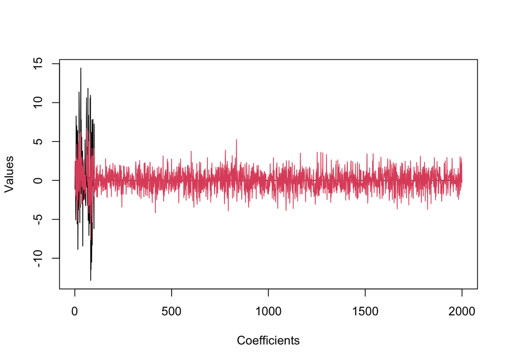

```r
#OGD, linear regression, true parameters in black, estimates in red.
plot(ts(regdata$b),xlab = "Coefficients",ylab = "Values")
lines(regogdemp$b_est,col=2)
```

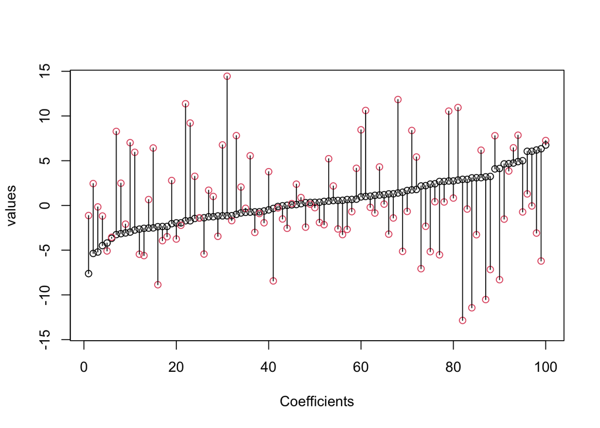

```r
#Plot the sorted estimates of the regression parameters for the signal variables for the case above.
plot(sort(regogdemp$b_est[1:100]),xlab = "Coefficients", ylab = "values",ylim = c(-14,14))
points(regdata$b[order(sort(regogdemp$b_est[1:100]))],col = 2)
segments(x0 = c(1:100), y0 = sort(regogdemp$b_est[1:100]), x1 =c(1:100), y1 = regdata$b[order(sort(regogdemp$b_est[1:100]))] )
```

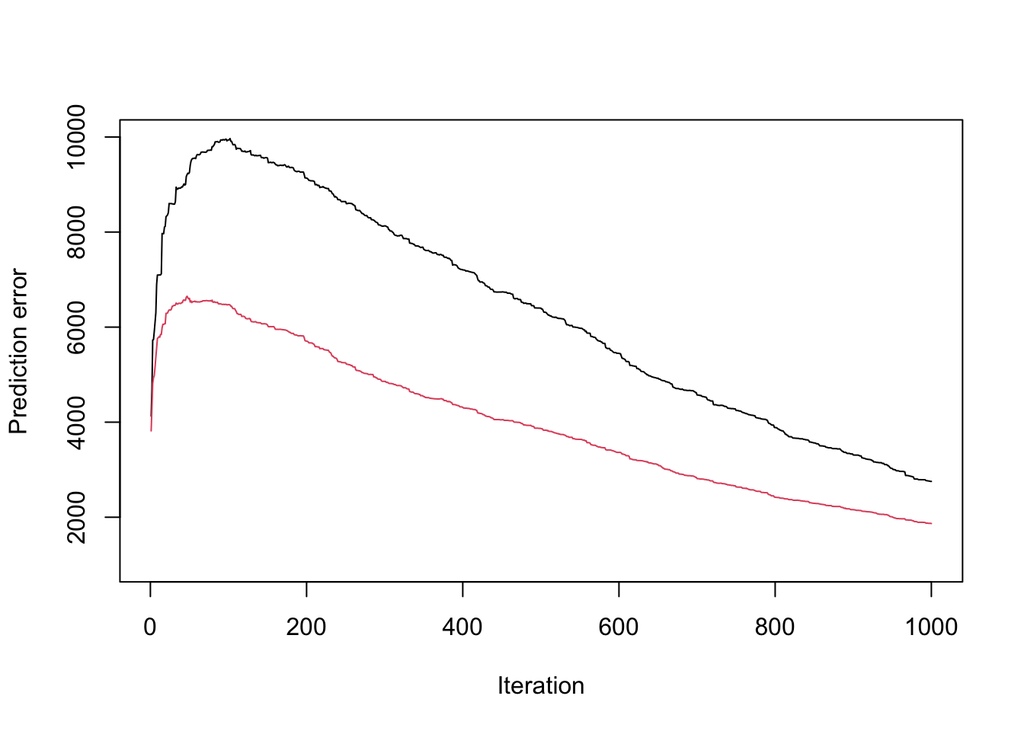

```r
#Prediction errors in the regression context from OGD and AdaGD
plot(regogdemp$pred_error,type = "l",ylim = c(1000,10000),xlab = "Iteration",ylab = "Prediction error")
lines(regagdemp$pred_error,col = 2)
```